# speeddatingproject

1. Introduction  
   1.1 Background  
   1.2 Data
2. Data Cleaning and EDA  
   2.1 What Do People Find Important?
   - What People Value in the Opposite Sex
   - What People Think Peers Value in the Opposite Sex
   - What People Think the Opposite Sex Values

   2.2 Instances of Unrequited Love
3. Modeling: Classification
4. Conclusion

# Introduction

## Background

Before dating apps became all the rage, there was this thing called speed dating that was meant to be a fun way to cut down on the mountains of time individuals spent trying to find a partner. Speed dating was a solution that allowed one to meet and interact with a large number of potential partners in a relatively short amount of time -- often just 4 minutes, as in this experiment. In this report, I want to dissect what people are looking for in their speed dating matches, if there exist gender differences (which will be limited to male and female in this dataset), and other factors (such as the order in which people met potential partners) that might influence peoples' decisions.

## Data

The dataset we will explore was drawn from "Speed Dating Experiment", found on Kaggle.com. Through a series of speed dating experiments conducted from 2002-2004 by Columbia Business School professors Ray Fisman and Sheena Iyengar for their paper [Gender Differences in Mate Selection: Evidence From a Speed Dating Experiment](https://faculty.chicagobooth.edu/emir.kamenica/documents/genderDifferences.pdf), a dataset compiling demographics, dating habits, lifestyle information, and various attributes was collected. When participants signed up, they filled out a baseline survey. Then participants rated each other after each 4-minute interaction. Finally, individuals were asked if they would like a second date with any of the potential partners they met during the experiment, and rated them again on similar questions as their own baseline survey. Note that these experiments collected information from heterosexual male-identifying and heterosexual female-identifying individuals.

For more analysis from Iyengar and Fisman, read [Racial Preferences in Dating](https://faculty.chicagobooth.edu/emir.kamenica/documents/racialpreferences.pdf).

- 552 participants in the experiment from 2002-2004
- Dates were 4 minutes long
- Survey questions included in dataset:
  - If they would like to see their date again
  - Attractiveness
  - Sincerity
  - Intelligence
  - Fun
  - Ambition
  - Shared Interests
- Participant information collected:
  - Demoraphics
  - Dating habits
  - Self-perceptions across key attributes
  - Beliefs on what others find valuable in a mate
  - Lifestyle information

Questions were asked in 3 stages:

1. Before the date
2. After the date
3. 3-4 weeks after the date

Further reading:

- https://www.bbc.com/future/article/20191112-how-dating-app-algorithms-predict-romantic-desire
- https://www.vox.com/2019/2/7/18210998/tinder-algorithm-swiping-tips-dating-app-science?__c=1

```python
#importing relevant lib and packages
import pandas as pd
pd.options.display.max_rows = 1000
import matplotlib.pyplot as plt
%matplotlib inline

import numpy as np
import seaborn as sns
import statsmodels.api as sm

from sklearn.model_selection import train_test_split
from sklearn.linear_model import LogisticRegression
from sklearn.ensemble import RandomForestClassifier
from sklearn.ensemble import GradientBoostingClassifier
from sklearn import metrics

from stargazer.stargazer import Stargazer
from IPython.core.display import HTML

import warnings
warnings.filterwarnings('ignore')
```

```python
#importing dataset
data = pd.read_csv('Speed Dating Data.csv', encoding='ISO-8859-1')
#Seeing attribute types
data.info(verbose = True);
```

```
<class 'pandas.core.frame.DataFrame'>
RangeIndex: 8378 entries, 0 to 8377
Data columns (total 195 columns):
 #   Column    Dtype
---  ------    -----
 0   iid       int64
 1   id        float64
 2   gender    int64
 3   idg       int64
 4   condtn    int64
 5   wave      int64
 6   round     int64
 7   position  int64
 8   positin1  float64
 9   order     int64
```

[output cut: 187 more lines]

```python
#counting null values
data.isnull().sum();
```

# Data Cleaning and EDA

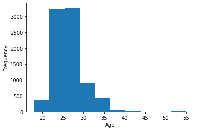

```python
# age distribution of participants
age = data[np.isfinite(data['age'])]['age']
plt.hist(age.values)
plt.xlabel('Age')
plt.ylabel('Frequency')
```

By viewing the plot above, we can see that most of the participants were in their mid 20's - early 30's. Let's look at how many people actually matched.

```python
pd.crosstab(index=data['match'], columns='count')
```

| col_0 match | count |
| --- | --- |
| 0 | 6998 |
| 1 | 1380 |

```python
# segmenting the dataset
data_1 = data.iloc[:, 11:28]
data_2 = data.iloc[:, 30:35]
data_3 = data.iloc[:, 39:43]
data_4 = data.iloc[:, 45:67]
data_5 = data.iloc[:, 69:74]
data_6 = data.iloc[:, 87:91]
data_7 = data.iloc[:, 97:102]
data_8 = data.iloc[:, 104:107]


date = pd.concat([data.iloc[:, 0],data.iloc[:, 2],data_1,data_2,data_3,data_4,data_5,
                  data_6,data_7,data_8], axis=1)
```

```python
# counting null values
date.isnull().sum();
```

```python
# removing null rows now that nulls are in the hundreds instead of thousands
date2 = date.dropna()
```

```python
# creating an object- free data frame
date3 = date2.drop(['field', 'from', 'career'], axis=1)
```

## What Do People Find Important?

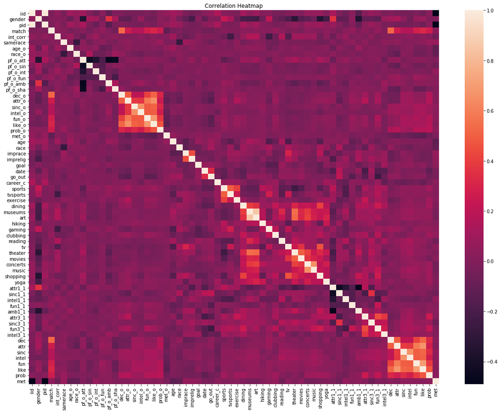

```python
# heat map
plt.subplots(figsize=(20,15))
ax = plt.axes()
ax.set_title('Correlation Heatmap')
corr = date3.corr()
sns.heatmap(corr,
           xticklabels=corr.columns.values,
           yticklabels=corr.columns.values)
```

Looking at the heatmap above, we can see that men seem to have a preference for attractive partners (attr1_1) while women seem to have a preference for ambitious partners (amb1_1). We can also see that apparently women like shopping and yoga more than men, and men like gaming more than women. Next, we'll see if there is a difference in match rate between the two genders identified at the time of this study.

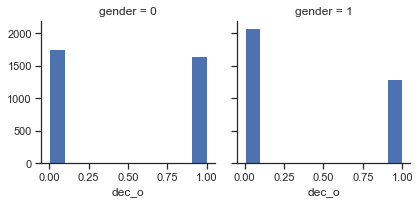

```python
# looking at dec_o by gender
sns.set(style="ticks", color_codes=True)
g = sns.FacetGrid(date3, col="gender")
g = g.map(plt.hist, "dec_o")
plt.ticklabel_format(useOffset=False, style='plain')
```

```python
# chi-square test
gender_crosstab = pd.crosstab(index=date3.gender, columns=date3.dec_o)
gender_table = sm.stats.Table(gender_crosstab)
gender_rslt = gender_table.test_nominal_association()
gender_rslt.pvalue
```

```
1.1102230246251565e-16
```

1. What people say they look for most in the opposite sex
2. What they think MOST of their fellow men/women look for in the opposite sex
3. What they think the opposite sex looks for in a date

We will break this further down into 3 phases for both men and women:

1. Before the date
2. After the date
3. 3-4 weeks after the date

```python
# prepping data
def dataprep(dataset, cols):
    dataset2 = dataset[dataset[cols].notnull().all(1)]
    dataset2 = dataset2.groupby("gender").agg(AvgAttractive1 = pd.NamedAgg(column = cols[0], aggfunc = np.mean),
                                          AvgSincere1 = pd.NamedAgg(column = cols[1], aggfunc = np.mean),
                                          AvgIntel1 = pd.NamedAgg(column = cols[2], aggfunc = np.mean),
                                          AvgFun1 = pd.NamedAgg(column = cols[3], aggfunc = np.mean),
                                          AvgAmb1 = pd.NamedAgg(column = cols[4], aggfunc = np.mean),
                                          AvgShar1 = pd.NamedAgg(column = cols[5], aggfunc = np.mean))
    # filtering for men
    perceptionsummary = perceptionanalysis(dataset2)
    perceptionsummary_male = perceptionsummary[perceptionsummary.index == 1]
    perceptionsummary_male['Score'] = pd.DataFrame(np.round(perceptionsummary_male['Score']))


    # filtering for women
    perceptionsummary_female = perceptionsummary[perceptionsummary.index == 0]
    perceptionsummary_female['Score'] = pd.DataFrame(np.round(perceptionsummary_female['Score']))

    return pd.DataFrame(perceptionsummary_male), pd.DataFrame(perceptionsummary_female)
```

```python
# creates dataset of only rated characteristics
def perceptionanalysis(dataset):
    attractiveonly = pd.DataFrame(dataset.loc[:, "AvgAttractive1"])
    attractiveonly = attractiveonly.rename(columns = {"AvgAttractive1": "Score"})
    attractiveonly["Type of Attribute"] = ["Attractive", "Attractive"]

    sincereonly = pd.DataFrame(dataset.loc[:, "AvgSincere1"])
    sincereonly = sincereonly.rename(columns = {"AvgSincere1": "Score"})
    sincereonly["Type of Attribute"] = ["Sincere", "Sincere"]

    funonly = pd.DataFrame(dataset.loc[:, "AvgFun1"])
    funonly = funonly.rename(columns = {"AvgFun1": "Score"})
    funonly["Type of Attribute"] = ["Fun", "Fun"]

    ambonly = pd.DataFrame(dataset.loc[:, "AvgAmb1"])
    ambonly = ambonly.rename(columns = {"AvgAmb1": "Score"})
    ambonly["Type of Attribute"] = ["Ambitious", "Ambitious"]

    sharonly = pd.DataFrame(dataset.loc[:, "AvgShar1"])
    sharonly = sharonly.rename(columns = {"AvgShar1": "Score"})
    sharonly["Type of Attribute"] = ["Shared Interests", "Shared Interests"]

    intelonly = pd.DataFrame(dataset.loc[:, "AvgIntel1"])
    intelonly = intelonly.rename(columns = {"AvgIntel1": "Score"})
    intelonly["Type of Attribute"] = ["Intelligent", "Intelligent"]

    return pd.concat([attractiveonly, sincereonly, funonly, ambonly, sharonly, intelonly])
```

```python
def graphproducer(dataframe, cols, title):
    df = dataprep(dataframe, cols)[0]
    df2 = dataprep(dataframe, cols)[1]
    fig, (ax, ax2) = plt.subplots(ncols = 2, sharey = False, constrained_layout = True)

    df.sort_values(by = "Score").plot(kind = "barh", x = "Type of Attribute", y = "Score", legend = False, ax = ax, title = "Men")
    df2.sort_values(by = "Score").plot(kind = "barh", x = "Type of Attribute", y = "Score", legend = False, ax = ax2, color = "gold", title = "Women", figsize = [10, 4])
    ax.set_xlabel("Score")
    ax2.set_xlabel("Score")
    fig.suptitle(title, ha = "center")
```

### What People Value in the Opposite Sex

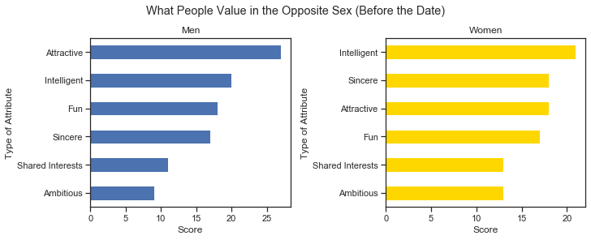

```python
perceptions = data
cols = ['attr1_1', 'sinc1_1', 'intel1_1', 'fun1_1', 'amb1_1', 'shar1_1']
graphproducer(perceptions, cols, "What People Value in the Opposite Sex (Before the Date)")
```

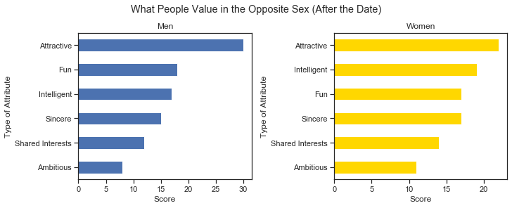

```python
cols_1b = ['attr1_2', 'sinc1_2', 'intel1_2', 'fun1_2', 'amb1_2', 'shar1_2']
graphproducer(perceptions, cols_1b, "What People Value in the Opposite Sex (After the Date)")
```

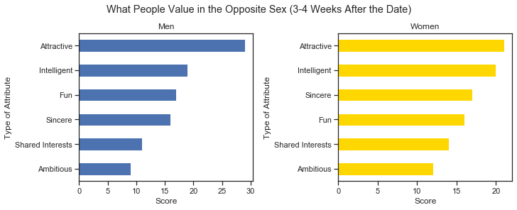

```python
cols_1c = ['attr1_3', 'sinc1_3', 'intel1_3', 'fun1_3', 'amb1_3', 'shar1_3']
graphproducer(perceptions, cols_1c, "What People Value in the Opposite Sex (3-4 Weeks After the Date)")
```

### What People Think Peers Value in the Opposite Sex

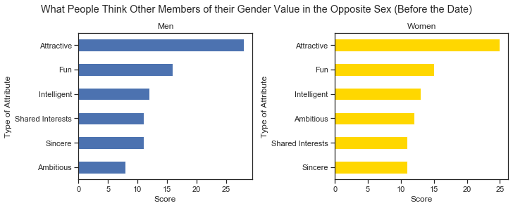

```python
cols_2a = ['attr4_1', 'sinc4_1', 'intel4_1', 'fun4_1', 'amb4_1', 'shar4_1']
graphproducer(perceptions, cols_2a, "What People Think Other Members of their Gender Value in the Opposite Sex (Before the Date)")
```

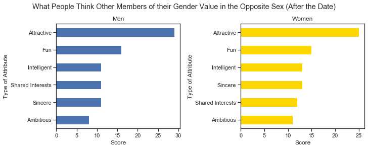

```python
cols_2b = ['attr4_2', 'sinc4_2', 'intel4_2', 'fun4_2', 'amb4_2', 'shar4_2']
graphproducer(perceptions, cols_2b, "What People Think Other Members of their Gender Value in the Opposite Sex (After the Date)")
```

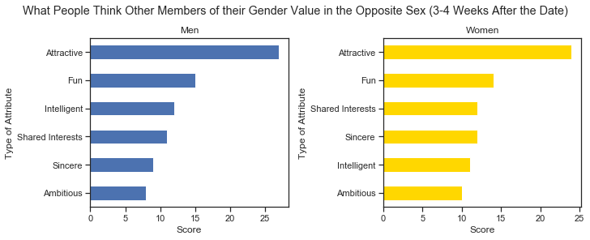

```python
cols_2c = ['attr4_3', 'sinc4_3', 'intel4_3', 'fun4_3', 'amb4_3', 'shar4_3']
graphproducer(perceptions, cols_2c, "What People Think Other Members of their Gender Value in the Opposite Sex (3-4 Weeks After the Date)")
```

### What People Think the Opposite Sex Values

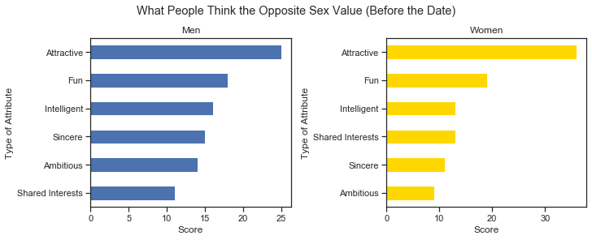

```python
cols_3a = ['attr2_1', 'sinc2_1', 'intel2_1', 'fun2_1', 'amb2_1', 'shar2_1']
graphproducer(perceptions, cols_3a, "What People Think the Opposite Sex Value (Before the Date)")
```

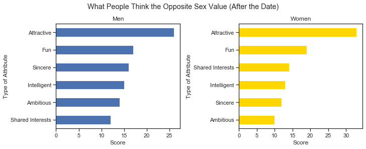

```python
cols_3b = ['attr2_2', 'sinc2_2', 'intel2_2', 'fun2_2', 'amb2_2', 'shar2_2']
graphproducer(perceptions, cols_3b, "What People Think the Opposite Sex Value (After the Date)")
```

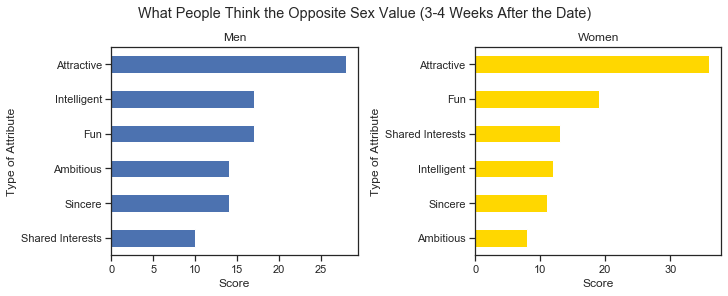

```python
cols_3c = ['attr2_3', 'sinc2_3', 'intel2_3', 'fun2_3', 'amb2_3', 'shar2_3']
graphproducer(perceptions, cols_3c, "What People Think the Opposite Sex Value (3-4 Weeks After the Date)")
```

Next, we will examine the **potential link between shared interests and match rate**.

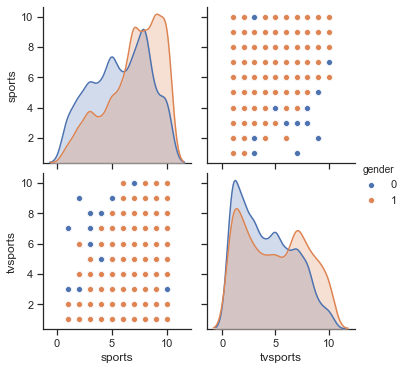

```python
# just for fun, looking at interest overlap
sns.set(style="ticks", color_codes=True)
date_int = pd.concat([date3.iloc[:, 1],date3.iloc[:, 30:32]],axis = 1)
g = sns.pairplot(date_int, hue="gender")
```

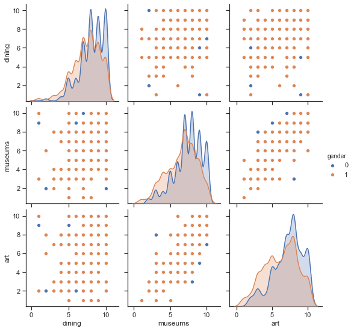

```python
# just for fun, looking at interest overlap
sns.set(style="ticks", color_codes=True)
date_int = pd.concat([date3.iloc[:, 1],date3.iloc[:, 33:36]],axis = 1)
g = sns.pairplot(date_int, hue="gender")
```

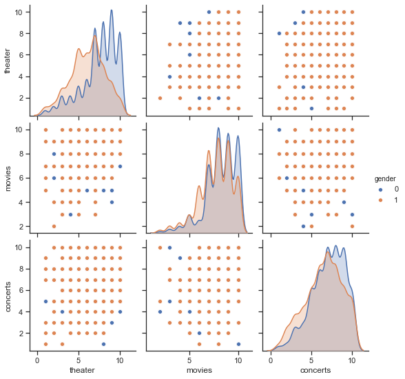

```python
# just for fun, looking at interest overlap
sns.set(style="ticks", color_codes=True)
date_int2 = pd.concat([date3.iloc[:, 1],date3.iloc[:, 41:44]],axis = 1)
g = sns.pairplot(date_int2, hue="gender")
```

A safe date to suggest according to a male/female gender breakdown might be movies and dining. However, these interests don't really correlate to a match, so I will remove interests from my match prediction model.

It looks like match is most correlated to the decisions of the partners (by construction), and the partner's attributes. We see very little correlation between match and age or race or interests.

```python
# removing interests
date4 = date3.drop(['sports', 'tvsports', 'exercise', 'dining', 'museums', 'art', 'hiking',
                    'gaming', 'clubbing', 'reading', 'tv', 'theater', 'movies', 'concerts', 'music',
                   'shopping', 'yoga'], axis=1)
```

## How Many Interactions Were Unrequited Love?

Meaning one party indicated they were interested but the other party declined. That is, wwhere dec_o = 1 and dec = 0 OR dec = 1 and dec_o = 0.

```python
# unrequited love count
no_love_count = len(date4[(date4['dec_o']==0) & (date4['dec']==1)])
+ len(date4[(date4['dec_o']==1) & (date4['dec']==0)])
perc_broken_heart = no_love_count / len(date4.index)
perc_broken_heart*100
```

```
26.040900397234072
```

This means that 26% of participants did not match with someone who indicated interest in them. This is higher than the percentage of people who got a second date.

Do the incidences of unrequited love differ according to attractiveness of the partner?

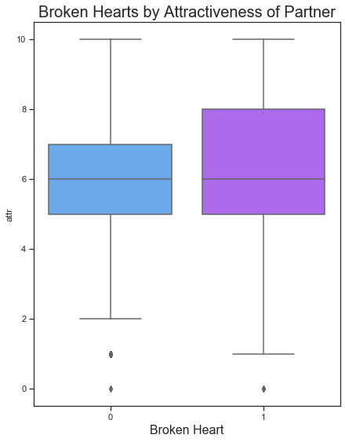

```python
# encoding unrequited love as a new column
date4['url']=np.where(((date4['dec_o']==0) & (date4['dec']==1))|((date4['dec']==0) & (date4['dec_o']==1)),1,0)

# looking at url by attractiveness
plt.figure(figsize=(7,9))
sns.boxplot(x='url', y='attr', data=date4, palette='cool')
plt.title('Broken Hearts by Attractiveness of Partner', fontsize=20)
plt.xlabel('Broken Heart', fontsize=16)
```

```python
# chi-square test
bh_crosstab = pd.crosstab(index=date4.attr, columns=date4.url)
bh_table = sm.stats.Table(bh_crosstab)
bh_rslt = bh_table.test_nominal_association()
bh_rslt.pvalue
```

```
0.5300021303134917
```

The difference in attractiveness per partner was not statistically significant. This is hopeful, because it means that the likelihood of getting rejected is not dependent on your attractiveness!

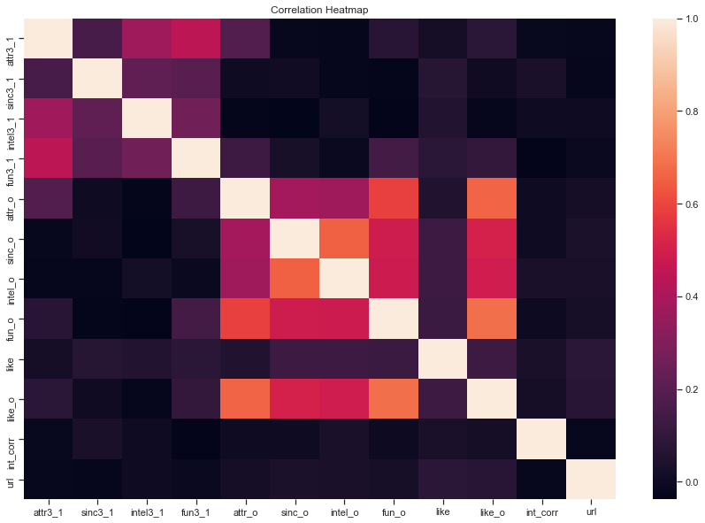

```python
date5 = pd.concat([date4['attr3_1'],date4['sinc3_1'],date4['intel3_1'],date4['fun3_1'],date4['attr_o'],
                   date4['sinc_o'],date4['intel_o'],date4['fun_o'],date4['like'],date4['like_o'],
                   date4['int_corr'],date4['url']],axis=1)
plt.subplots(figsize=(15,10))
ax = plt.axes()
ax.set_title("Correlation Heatmap")
corr = date5.corr()
sns.heatmap(corr,
            xticklabels=corr.columns.values,
            yticklabels=corr.columns.values)
```

This heatmap confirms our assertion that attractiveness does not determine your likelihood of experiencing unrequited love. It looks like your attractiveness (attr3_1) is only weakly correlated with how attractive your date finds you (attr_o). In fact, there is nearly zero correlation between how smart your sincere you think you are versus how smart and sincere your date thinks you are.

This brings us to the question of which out of all the personal attributes (attractiveness, sincereity, intelligence, fun, ambition, and liking) is the most influential for the final decision? For this, we will run a linear regression model.

```python
# OLS model with coefficients
X_ols = date4[['attr','sinc','intel','fun','like','int_corr']]
y_ols = date4.dec
traits = sm.OLS(y_ols, X_ols)
results_traits = traits.fit()
results_traits.summary()
```

OLS Regression Results

| Dep. Variable: | dec | R-squared (uncentered): | 0.602 |
| --- | --- | --- | --- |
| Model: | OLS | Adj. R-squared (uncentered): | 0.602 |
| Method: | Least Squares | F-statistic: | 1712. |
| Date: | Fri, 03 Jul 2020 | Prob (F-statistic): | 0.00 |
| Time: | 16:11:49 | Log-Likelihood: | -3686.4 |
| No. Observations: | 6797 | AIC: | 7385. |
| Df Residuals: | 6791 | BIC: | 7426. |
| Df Model: | 6 |  |  |
| Covariance Type: | nonrobust |  |  |

|  | coef | std err | t | P>\|t\| | [0.025 | 0.975] |
| --- | --- | --- | --- | --- | --- | --- |
| attr | 0.0555 | 0.004 | 15.678 | 0.000 | 0.049 | 0.062 |
| sinc | -0.0351 | 0.004 | -8.750 | 0.000 | -0.043 | -0.027 |
| intel | -0.0485 | 0.004 | -11.897 | 0.000 | -0.057 | -0.041 |
| fun | 0.0173 | 0.004 | 4.495 | 0.000 | 0.010 | 0.025 |
| like | 0.0997 | 0.004 | 22.261 | 0.000 | 0.091 | 0.109 |
| int_corr | -0.0366 | 0.017 | -2.210 | 0.027 | -0.069 | -0.004 |

| Omnibus: | 4603.362 | Durbin-Watson: | 1.535 |
| --- | --- | --- | --- |
| Prob(Omnibus): | 0.000 | Jarque-Bera (JB): | 394.555 |
| Skew: | 0.072 | Prob(JB): | 2.11e-86 |
| Kurtosis: | 1.828 | Cond. No. | 50.1 |

Warnings:  
[1] Standard Errors assume that the covariance matrix of the errors is correctly specified.

From the regression above, we see that being intelligent, sincere, or having similar interests slightly hurts your chances at getting a second date. This seems a little counterintuitive, but may have something to do with the 4 minute speed dating time limit. This might suggest that when it comes to first dates, to focus on being fun and likeable if the goal is to get a second date.

Let's run an OLS model with both respondents' ratings instead of only one side, this time with the dependent variable being match instead of decision.

```python
# OLS model with coefficients
X_ols = date4[['dec','dec_o','attr','attr_o','fun','fun_o','like','like_o','int_corr']]
y_ols = date4.match
traits = sm.OLS(y_ols, X_ols)
results_traits = traits.fit()
results_traits.summary()
```

OLS Regression Results

| Dep. Variable: | match | R-squared (uncentered): | 0.647 |
| --- | --- | --- | --- |
| Model: | OLS | Adj. R-squared (uncentered): | 0.646 |
| Method: | Least Squares | F-statistic: | 1381. |
| Date: | Fri, 03 Jul 2020 | Prob (F-statistic): | 0.00 |
| Time: | 16:11:49 | Log-Likelihood: | -180.33 |
| No. Observations: | 6797 | AIC: | 378.7 |
| Df Residuals: | 6788 | BIC: | 440.1 |
| Df Model: | 9 |  |  |
| Covariance Type: | nonrobust |  |  |

|  | coef | std err | t | P>\|t\| | [0.025 | 0.975] |
| --- | --- | --- | --- | --- | --- | --- |
| dec | 0.4463 | 0.007 | 62.145 | 0.000 | 0.432 | 0.460 |
| dec_o | 0.4463 | 0.007 | 62.417 | 0.000 | 0.432 | 0.460 |
| attr | -0.0013 | 0.002 | -0.584 | 0.559 | -0.005 | 0.003 |
| attr_o | -0.0009 | 0.002 | -0.406 | 0.685 | -0.005 | 0.003 |
| fun | 0.0006 | 0.002 | 0.249 | 0.803 | -0.004 | 0.005 |
| fun_o | 0.0012 | 0.002 | 0.555 | 0.579 | -0.003 | 0.006 |
| like | -0.0161 | 0.003 | -6.132 | 0.000 | -0.021 | -0.011 |
| like_o | -0.0170 | 0.003 | -6.523 | 0.000 | -0.022 | -0.012 |
| int_corr | 0.0036 | 0.010 | 0.364 | 0.716 | -0.016 | 0.023 |

| Omnibus: | 33151.792 | Durbin-Watson: | 1.869 |
| --- | --- | --- | --- |
| Prob(Omnibus): | 0.000 | Jarque-Bera (JB): | 814.640 |
| Skew: | 0.256 | Prob(JB): | 1.27e-177 |
| Kurtosis: | 1.383 | Cond. No. | 51.3 |

Warnings:  
[1] Standard Errors assume that the covariance matrix of the errors is correctly specified.

From the coefficients above, it looks that what really matters is the decision of both participants in securing a second date, rather than what their ratings were of one another. This may seem a little trivial, but by construction it would stand to reason that the most important determinant in whether a pairing will match is whether or not they both select each other in the final decision, not necessarily how they rated everyone present at the speed dating experiment in absolute terms.

# Modeling: Classification

```python
# preparing the data
X=date4[['like','dec']]
y=date4['match']
X_train, X_test, y_train, y_test = train_test_split(X, y, test_size=0.2, random_state=0, stratify=y)
```

```python
# logistic regression classification model
model = LogisticRegression(C=1, random_state=0)
lrc = model.fit(X_train, y_train)
predict_train_lrc = lrc.predict(X_train)
predict_test_lrc = lrc.predict(X_test)
print('Training Accuracy:', metrics.accuracy_score(y_train, predict_train_lrc))
print('Validation Accuracy:', metrics.accuracy_score(y_test, predict_test_lrc))
```

```
Training Accuracy: 0.8282140886518301
Validation Accuracy: 0.8279411764705882
```

Let's try more models to see if we can get a better match prediction.

```python
# random forest model
model = RandomForestClassifier()
rf_model = model.fit(X_train, y_train)
predict_train_rf = rf_model.predict(X_train)
predict_test_rf = rf_model.predict(X_test)
print('Training Accuracy:', metrics.accuracy_score(y_train, predict_train_rf))
print('Validation Accuracy:', metrics.accuracy_score(y_test, predict_test_rf))
```

```
Training Accuracy: 0.8289497884862976
Validation Accuracy: 0.8272058823529411
```

```python
# xgboost model
model = GradientBoostingClassifier()
xgb_model = model.fit(X_train, y_train)
predict_train_xgb = xgb_model.predict(X_train)
predict_test_xgb = xgb_model.predict(X_test)
print('Training Accuracy:', metrics.accuracy_score(y_train, predict_train_xgb))
print('Validation Accuracy:', metrics.accuracy_score(y_test, predict_test_xgb))
```

```
Training Accuracy: 0.8289497884862976
Validation Accuracy: 0.8272058823529411
```

# Conclusion

This data exploration didn't really give us any better answers to the secrets of love, or at least mastering the first date. It's not shared interests or hobbies, it's not attractiveness or intelligence or other commonly thought to be important traits. It's just how much someone likes you, which we see reflected in the variables `dec_o` and `dec`.